# Rep data assignment

Aftab

9/17/2020

**loading required package**

```r
library(tidyverse)
library(tibble)
library(lubridate)
library(knitr)
library(markdown)
library(rmarkdown)
```

**Loading and preprocessing the data:**

*step1:Loading data*

```r
Repdata <- as_tibble(read.csv("E://Analysis Projects/activity.csv"))
```

*step2:Proccessing data into suitable format*

```r
Repdata$date <- as.Date(Repdata$date,"%Y-%m-%d")
proccessed_Repdata <- Repdata%>%
                              separate(date,
                                       into = c("year","month","day"),
                                       sep = "-",
                                       remove = T)
proccessed_Repdata
```

```
## # A tibble: 17,568 x 5
##    steps year  month day   interval
##    <int> <chr> <chr> <chr>    <int>
##  1    NA 2012  10    01           0
##  2    NA 2012  10    01           5
##  3    NA 2012  10    01          10
##  4    NA 2012  10    01          15
##  5    NA 2012  10    01          20
##  6    NA 2012  10    01          25
##  7    NA 2012  10    01          30
##  8    NA 2012  10    01          35
##  9    NA 2012  10    01          40
## 10    NA 2012  10    01          45
## # ... with 17,558 more rows
```

**Q1: What is mean total number of steps taken per day?**

*step1: Making a histogram of the total number of steps taken each day*

```r
steps_per_day <- Repdata%>%
     group_by(date)%>%
     summarize(total_steps_per_day=sum(steps,na.rm=T))%>%
     ungroup()
```

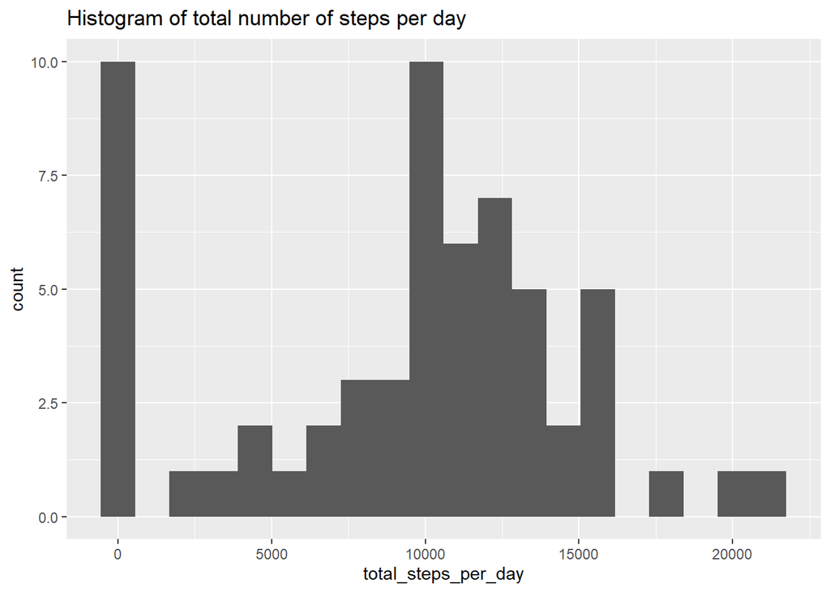

```r
steps_per_day%>%
     ggplot(aes(total_steps_per_day))+
     geom_histogram(bins = 20)+
     labs(title = "Histogram of total number of steps per day")
```

*step2: Calculating mean and median total number of steps taken per day:*

```r
mean(steps_per_day$total_steps_per_day)
```

```
## [1] 9354.23
```

```r
median(steps_per_day$total_steps_per_day)
```

```
## [1] 10395
```

**Q2: What is the average daily activity pattern?**

*Step1: Make a time series plot (i.e. type = “l”) of the 5-minute interval (x-axis) and the average number of steps taken, averaged across all days (y-axis)*

```r
steps_per_interval <- Repdata%>%
          group_by(interval)%>%
          summarize(mean_steps_per_interval=mean(steps,
                                                na.rm=T))
```

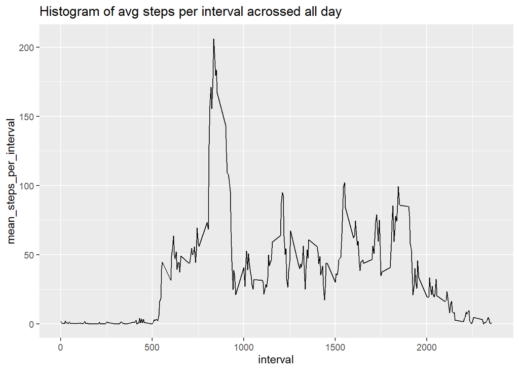

```r
steps_per_interval%>%
    ggplot(aes(interval,mean_steps_per_interval))+
    geom_line()+
    labs(title = "Histogram of avg steps per interval acrossed all day")
```

*step2: finding which 5-minute interval, on average across all the days in the dataset, contains the maximum number of steps*

```r
max_steps <- steps_per_interval%>%arrange(desc(mean_steps_per_interval))
max_steps
```

```
## # A tibble: 288 x 2
##    interval mean_steps_per_interval
##       <int>                   <dbl>
##  1      835                    206.
##  2      840                    196.
##  3      850                    183.
##  4      845                    180.
##  5      830                    177.
##  6      820                    171.
##  7      855                    167.
##  8      815                    158.
##  9      825                    155.
## 10      900                    143.
## # ... with 278 more rows
```

So from this we can say on average 835-840 interval has the highest steps count among all intervals.

**Q3: Imputing missing values**

*step1:Calculate and report the total number of missing values in the dataset*

```r
sum(is.na(Repdata$steps))
```

```
## [1] 2304
```

So there are 2304 missing values in the dataset.

*step2: Devise a strategy for filling in all of the missing values in the dataset. The strategy does not need to be sophisticated*

```r
#steps=ifelse(is.na(steps),mean(steps,na.rm=T),steps)
```

*step3:Creating a new dataset that is equal to the original dataset but with the missing data filled in*

```r
converted_repdata <- Repdata%>%
     group_by(interval)%>%
     mutate(steps=ifelse(is.na(steps),mean(steps,na.rm=T),steps))%>%
     mutate(steps=ifelse(is.na(steps),0,steps))
converted_repdata
```

```
## # A tibble: 17,568 x 3
## # Groups:   interval [288]
##     steps date       interval
##     <dbl> <date>        <int>
##  1 1.72   2012-10-01        0
##  2 0.340  2012-10-01        5
##  3 0.132  2012-10-01       10
##  4 0.151  2012-10-01       15
##  5 0.0755 2012-10-01       20
##  6 2.09   2012-10-01       25
##  7 0.528  2012-10-01       30
##  8 0.868  2012-10-01       35
##  9 0      2012-10-01       40
## 10 1.47   2012-10-01       45
## # ... with 17,558 more rows
```

*step4: Make a histogram of the total number of steps taken each day*

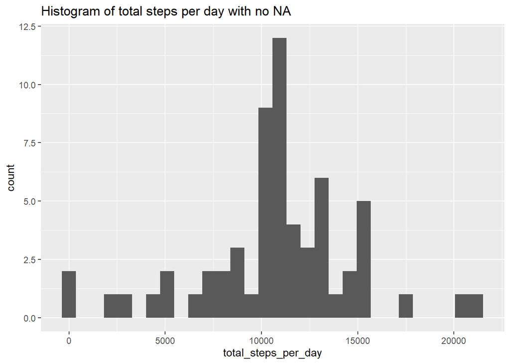

```r
converted_repdata%>%
     group_by(date)%>%
     summarize(total_steps_per_day=sum(steps))%>%
     ungroup()%>%
     ggplot(aes(total_steps_per_day))+
     geom_histogram()+
     labs(title = "Histogram of total steps per day with no NA")
```

*and Calculate and report the mean and median total number of steps taken per day. Do these values differ from the estimates from the first part of the assignment? What is the impact of imputing missing data on the estimates of the total daily number of steps?*

```r
steps_per_day_noNA <- converted_repdata%>%
          group_by(date)%>%
          summarize(total_steps_per_day=sum(steps))%>%
          ungroup()
mean(steps_per_day_noNA$total_steps_per_day)
```

```
## [1] 10766.19
```

```r
median(steps_per_day_noNA$total_steps_per_day)
```

```
## [1] 10766.19
```

Here we see mean is equal to the median. but both mean and median increased after the NA value is replaced.

**Q4: Are there differences in activity patterns between weekdays and weekends?**

*step1:Create a new factor variable in the dataset with two levels – “weekday” and “weekend” indicating whether a given date is a weekday or weekend day.*

```r
converted_repdata$days <- weekdays(converted_repdata$date)

converted_repdata_withDays <- converted_repdata%>%
        mutate(days=ifelse(days%in%c("Saturday","Sunday"),"weekend","weekday"))

converted_repdata_withDays
```

```
## # A tibble: 17,568 x 4
## # Groups:   interval [288]
##     steps date       interval days
##     <dbl> <date>        <int> <chr>
##  1 1.72   2012-10-01        0 weekday
##  2 0.340  2012-10-01        5 weekday
##  3 0.132  2012-10-01       10 weekday
##  4 0.151  2012-10-01       15 weekday
##  5 0.0755 2012-10-01       20 weekday
##  6 2.09   2012-10-01       25 weekday
##  7 0.528  2012-10-01       30 weekday
##  8 0.868  2012-10-01       35 weekday
##  9 0      2012-10-01       40 weekday
## 10 1.47   2012-10-01       45 weekday
## # ... with 17,558 more rows
```

```r
steps_by_days <-aggregate(converted_repdata_withDays$steps ~ converted_repdata_withDays$interval + converted_repdata_withDays$days, converted_repdata_withDays, mean)
```

*step2: Make a panel plot containing a time series plot (i.e. type = “l”) of the 5-minute interval (x-axis) and the average number of steps taken, averaged across all weekday days or weekend days (y-axis).*

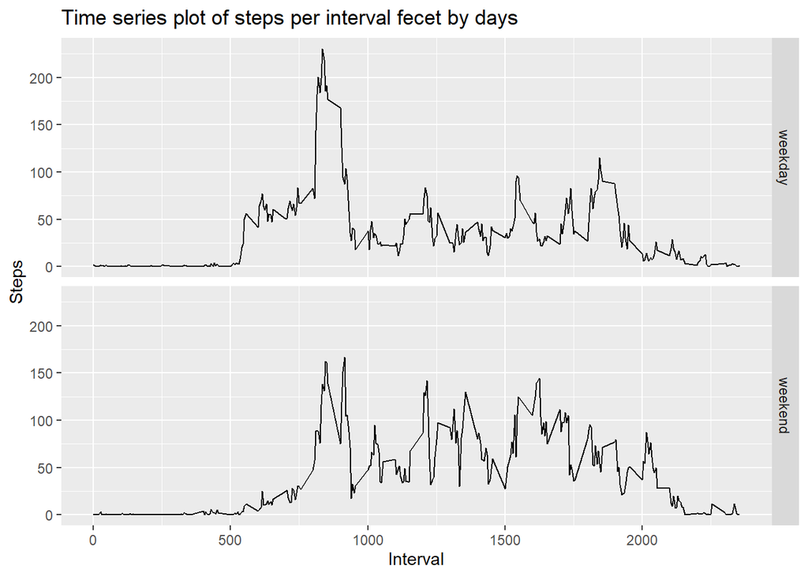

```r
names(steps_by_days) <- c("interval","days","steps")

steps_by_days%>%
    ggplot(aes(interval,steps))+
    geom_line()+
    facet_grid(days~.)+
    labs(title = "Time series plot of steps per interval fecet by days",
         x="Interval",
         y="Steps")
```